# JQ-coexpression-network

2023-06-23

### Introduction

The objective of co-expression network analysis is to find groups of transcripts that have coordinated expression patterns, and then to analyze the detected groups to understand higher-level trends in the data. Here, co-expression analysis is performed using RNA-seq data from Japanese quail liver that were exposed to eight different chemicals.

### Load packages

This script loads packages for the following tasks:

- **General data manipulation:** dplyr, reshape, data.table
- **Transcriptomics analysis:** WGCNA, DESeq2, limma, sva
- **Visualization:** ggplot2, ggpubr, pheatmap, RColorBrewer

```r
library(dplyr)
library(reshape)
library(data.table)
library(WGCNA)
library(DESeq2)
library(limma)
library(sva)
library(ggplot2)
library(ggpubr)
library(pheatmap)
library(RColorBrewer)
```

### Read in data

The following code reads in and formats the counts table and metadata table for the adult Japanese quail RNA-seq dataset.

```r
# read in adult data
bap.seme <- read.table("data/Kallisto_Adult_JQ_BaP_SeMe.txt")
cpf.ee2.tb <- read.table("data/Kallisto_Adult_JQ_CPF_EE2_TB.txt")
pb.flx.hbcd <- read.table("data/Kallisto_Adult_JQ_Pb_FLX_HBCD.txt")

# pull out meta data
bap.seme.meta <- read.table("data/Kallisto_Adult_JQ_BaP_SeMe.txt",
                            nrow = 5, comment.char = "&", row.names = 1) %>% t() %>% data.frame()
colnames(bap.seme.meta) <- c("sample", "chem", "dose", "batch", "lifestage")
cpf.ee2.tb.meta <- read.table("data/Kallisto_Adult_JQ_CPF_EE2_TB.txt",
                              nrow = 5, comment.char = "&", row.names = 1) %>% t() %>% data.frame()
colnames(cpf.ee2.tb.meta) <- c("sample", "chem", "dose", "batch", "lifestage")
pb.flx.hbcd.meta <- read.table("data/Kallisto_Adult_JQ_Pb_FLX_HBCD.txt",
                               nrow = 5, comment.char = "&", row.names = 1) %>% t() %>% data.frame()
colnames(pb.flx.hbcd.meta) <- c("sample", "chem", "dose", "batch", "lifestage")

# sum rows for same entrez ID
bap.seme <- aggregate(bap.seme[-1], bap.seme[1], sum)
cpf.ee2.tb <- aggregate(cpf.ee2.tb[-1], cpf.ee2.tb[1], sum)
pb.flx.hbcd <- aggregate(pb.flx.hbcd[-1], pb.flx.hbcd[1], sum)

# give new column names
colnames(bap.seme) <- c("entrez", as.character(bap.seme.meta$sample))
colnames(cpf.ee2.tb) <- c("entrez", as.character(cpf.ee2.tb.meta$sample))
colnames(pb.flx.hbcd) <- c("entrez", as.character(pb.flx.hbcd.meta$sample))

# merge together expression data
dat.expr.adult <- merge(bap.seme, cpf.ee2.tb, by = "entrez") %>%
  merge(., pb.flx.hbcd, by = "entrez")
rownames(dat.expr.adult) <- dat.expr.adult[, 1]
dat.expr.adult <- dat.expr.adult[, -1]

# merge together meta data
dat.meta.adult <- rbind(bap.seme.meta, cpf.ee2.tb.meta) %>%
  rbind(., pb.flx.hbcd.meta)

# remove files for ind batches
rm(bap.seme, bap.seme.meta, cpf.ee2.tb, cpf.ee2.tb.meta, pb.flx.hbcd, pb.flx.hbcd.meta)
```

### Filtering and normalization

Counts are filtered to remove those with low abundance and low variance, and normalized with the ‘varianceStabilizingTransformation’ from DESeq2 which has been shown to improve clustering performance. Variance filtering is performed after the varianceStabilizingTransformation.

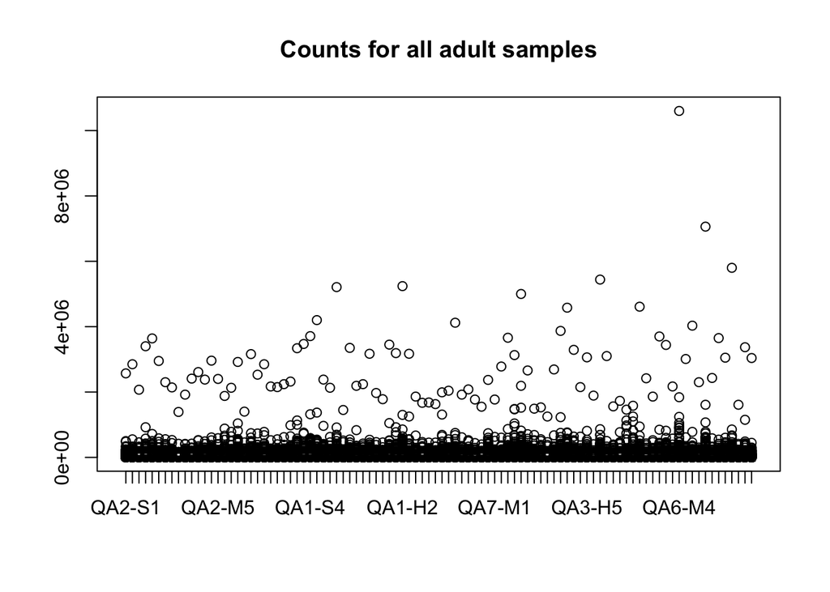

```r
# boxplot of counts
boxplot(dat.expr.adult, main = "Counts for all adult samples")
```

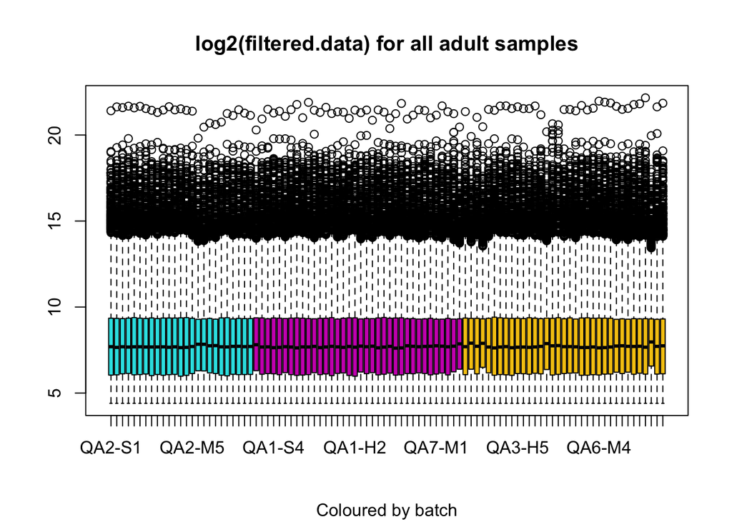

```r
# remove rows with < 10 counts
count.pass.adult <- apply(dat.expr.adult, 1, function(x) {x < 10})
count.pass.adult <- apply(count.pass.adult, 2, sum)
count.pass.adult <- names(count.pass.adult[count.pass.adult < 85])
dat.expr.adult <- dat.expr.adult[rownames(dat.expr.adult) %in% count.pass.adult, ] %>% as.matrix()
rm(count.pass.adult)

# convert to integer data instead of numeric
dat.expr.adult <- ceiling(dat.expr.adult)
mode(dat.expr.adult) <- "integer"

# do variance stabilizing transformation
dat.expr.adult <- varianceStabilizingTransformation(dat.expr.adult)

# Remove lowest 15th percentile with low variation
var.gene.adult <- apply(dat.expr.adult, 1, var)
var.15.adult <- quantile(var.gene.adult, 0.15)
var.pass.adult <- names(var.gene.adult[var.gene.adult > var.15.adult])
dat.expr.adult <- dat.expr.adult[rownames(dat.expr.adult) %in% var.pass.adult, ]

# boxplot after filtering/normalization
boxplot(dat.expr.adult, col = c(dat.meta.adult$batch),
        main = "log2(filtered.data) for all adult samples", sub = "Coloured by batch")
```

### Batch effect correction

The following code generates a PCA scores plot of the normalized data, from which we see that there is batch effect that should be corrected. After applying ComBat, the PCA scores plot is re-generated and we can see that the batch effect is no longer visible.

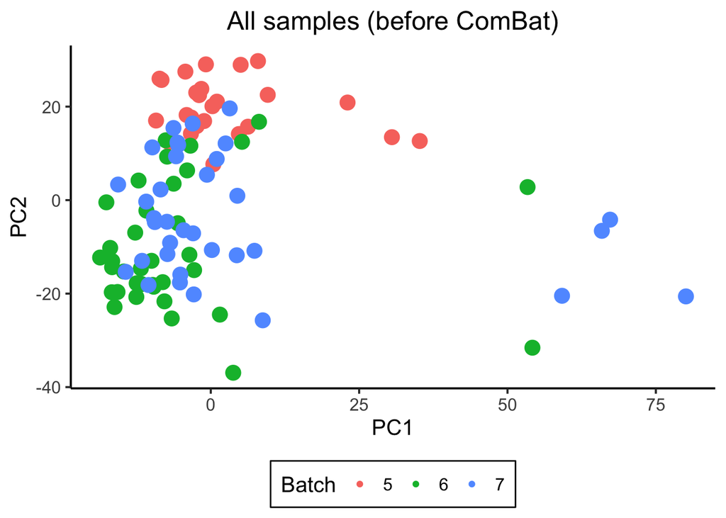

```r
# pca
pca.adult <- prcomp(t(dat.expr.adult))
pca.dat.adult <- pca.adult$x %>% data.frame()
pca.dat.adult$chem <- as.character(dat.meta.adult$chem)
pca.dat.adult$batch <- as.character(dat.meta.adult$batch)

# plot pca data - batch
ggplot(pca.dat.adult, aes(x = PC1, y = PC2, color = factor(unlist(batch)))) +
  geom_point(aes(size = 3)) +
  theme_classic(base_size = 15) +
  scale_size(guide = 'none') +
  theme(legend.position = 'bottom',
        legend.background = element_rect(color = "black", size = 0.5, linetype = "solid"),
        plot.title = element_text(hjust = 0.5)) +
  guides(color = guide_legend(title="Batch", legend.position = c(0.95,0.25))) +
  ggtitle("All samples (before ComBat)")
```

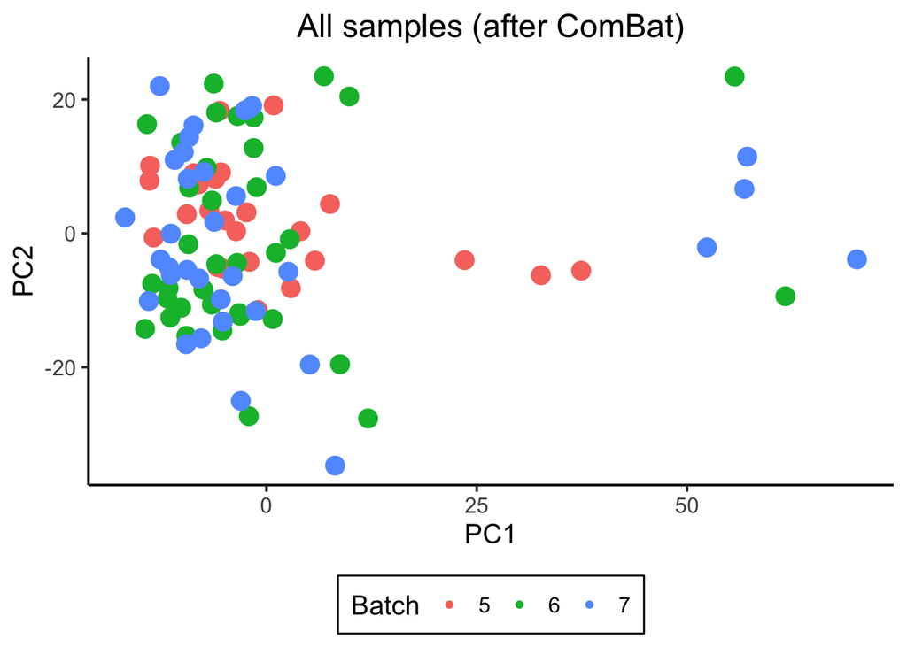

```r
# prepare combat input
batch.adult <- dat.meta.adult$batch
mod.combat.adult <- model.matrix(~1, data = dat.meta.adult)

# adjust for batch effect
dat.combat.adult <- ComBat(dat = dat.expr.adult, batch = batch.adult, mod = mod.combat.adult)

# pca
pca.adult <- prcomp(t(dat.combat.adult))
pca.dat.adult <- pca.adult$x %>% data.frame()
pca.dat.adult$batch <- as.character(dat.meta.adult$batch)
pca.dat.adult$chem <- as.character(dat.meta.adult$chem)

# plot pca data - batch
ggplot(pca.dat.adult, aes(x = PC1, y = PC2, color = factor(unlist(batch)))) +
  geom_point(aes(size = 3)) +
  theme_classic(base_size = 15) +
  scale_size(guide = 'none') +
  theme(legend.position = 'bottom',
        legend.background = element_rect(color = "black", size = 0.5, linetype = "solid"),
        plot.title = element_text(hjust = 0.5)) +
  guides(color = guide_legend(title="Batch", legend.position = c(0.95,0.25))) +
  ggtitle("All samples (after ComBat)")
```

### Detect outliers

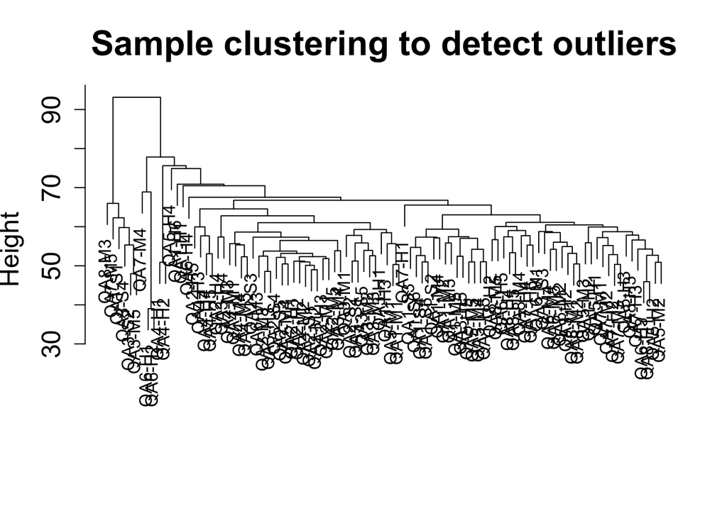

```r
# format expression and phenotype data (apical outcome)
datExprT.adult <- t(dat.expr.adult)
dat.trait.adult <- dat.meta.adult[,-c(1,5)]
dat.trait.adult$chem <- dat.trait.adult$chem %>% as.factor() %>% as.numeric()
dat.trait.adult$dose <- dat.trait.adult$dose %>% as.factor() %>% as.numeric()
dat.trait.adult$batch <- dat.trait.adult$batch %>% as.factor() %>% as.numeric()


traitColors.adult = numbers2colors(dat.trait.adult, signed = FALSE)

sampleTree.adult = hclust(dist(datExprT.adult), method = "average")
plot(sampleTree.adult, main = "Sample clustering to detect outliers", sub="", xlab="", cex.lab = 1.5,
     cex.axis = 1.5, cex.main = 2)
```

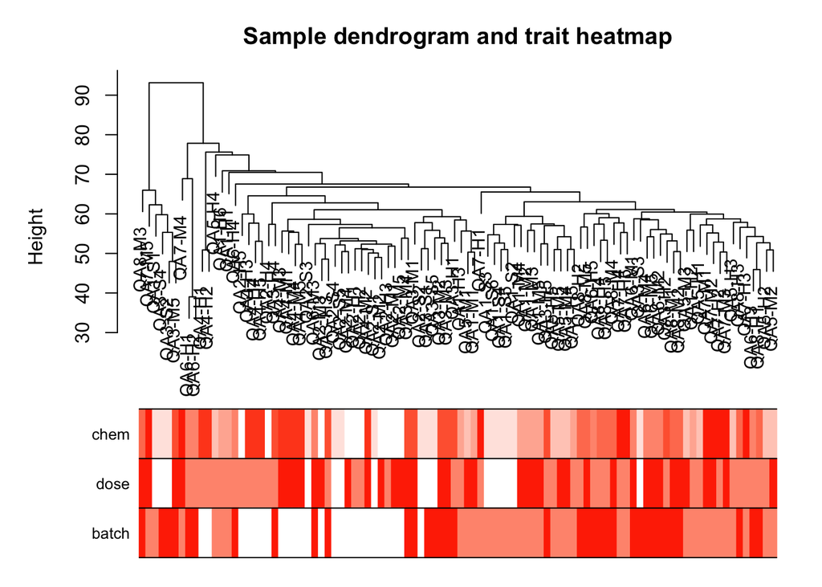

```r
plotDendroAndColors(sampleTree.adult, traitColors.adult,
                    groupLabels = names(dat.trait.adult),
                    main = "Sample dendrogram and trait heatmap")
```